# Homework #3

2/15/2018

## Tips at Restaurants

In this homework we will use the `tips` data set. THis data set is part of the `reshape2` package. You can load the data set by executing the command:

```r
data(tips, package="reshape2")
library(reshape2)
library(ggplot2)
library(dplyr)
```

The information contained in the data is collected by one waiter, who recorded over the course of a season information about each tip he received working in one restaurant. See `?tips` for a description of all of the variables.

1. Download the RMarkdown file with these homework instructions to use as a template for your work. Make sure to replace “Your Name” in the YAML with your name.
2. How many parties did the waiter serve? What type are the variables that he collected? Show your code.

```r
str(tips)
```

```
## 'data.frame':    244 obs. of  7 variables:
##  $ total_bill: num  17 10.3 21 23.7 24.6 ...
##  $ tip       : num  1.01 1.66 3.5 3.31 3.61 4.71 2 3.12 1.96 3.23 ...
##  $ sex       : Factor w/ 2 levels "Female","Male": 1 2 2 2 1 2 2 2 2 2 ...
##  $ smoker    : Factor w/ 2 levels "No","Yes": 1 1 1 1 1 1 1 1 1 1 ...
##  $ day       : Factor w/ 4 levels "Fri","Sat","Sun",..: 3 3 3 3 3 3 3 3 3 3 ...
##  $ time      : Factor w/ 2 levels "Dinner","Lunch": 1 1 1 1 1 1 1 1 1 1 ...
##  $ size      : int  2 3 3 2 4 4 2 4 2 2 ...
```

**There are 244 objects in the data frame so the waiter served 244 parties. total_bill and tip are numbers. The variables sex, smoker, day, and time are factors and size is an integer.**

3. How does the tipping amount (`tip`) depend on the overall bill (`total_bill`)? Use the `ggplot2` package to show a chart, describe the relationship in words. Describe at least two types of anomalies in the plot. What do they mean?

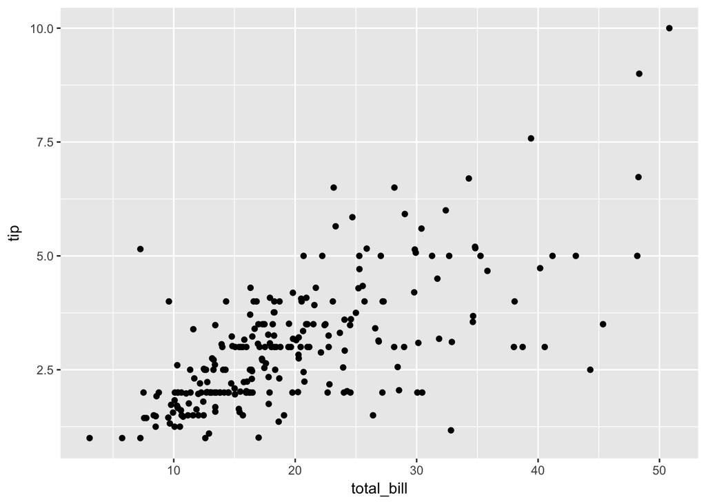

```r
ggplot(tips, aes(x=total_bill, y=tip)) + geom_point()
```

**There appears to be a positive linear relationship between the bill amount and the tip amount. As the bill gets larger so does the tip. This plot also contains several outliers. One example is the point with a total bill of approximately $6 and a tip over $5. The tip rate is much larger at this point than the average point. Another outlier is the bill for $30 with a tip of about $1. This is much lower than the average tip rate.**

4. Introduce a variable `tiprate` into the data set, that incorporates the rate of tips. What information is available for the best tipper, what for the worst? What is the average rate for tips?

```r
tips$tiprate <- tips$tip/tips$total_bill

filter(tips, tiprate==max(tips$tiprate))
```

```
##   total_bill  tip  sex smoker day   time size   tiprate
## 1       7.25 5.15 Male    Yes Sun Dinner    2 0.7103448
```

**The highest tip rate was by a Male on Sunday at dinner. His bill was $7.25 and he gave $5.15 tip. His tip rate was .7.**

```r
filter(tips, tiprate==min(tips$tiprate))
```

```
##   total_bill  tip  sex smoker day   time size    tiprate
## 1      32.83 1.17 Male    Yes Sat Dinner    2 0.03563814
```

**The lowest tip rate was by a male on Saturday for dinner. His bill was $32.83 and he gave $1.17 as a tip. His tip rate was 0.03.**

```r
mean(tips$tiprate)
```

```
## [1] 0.1608026
```

**The average tip rate was .16. This is about a 16% tip.**

6. How does smoking behavior and gender of the person who pays impact the relationship between tip and total bill? Find a visualization that incorporates all four variables. Interpret the result.

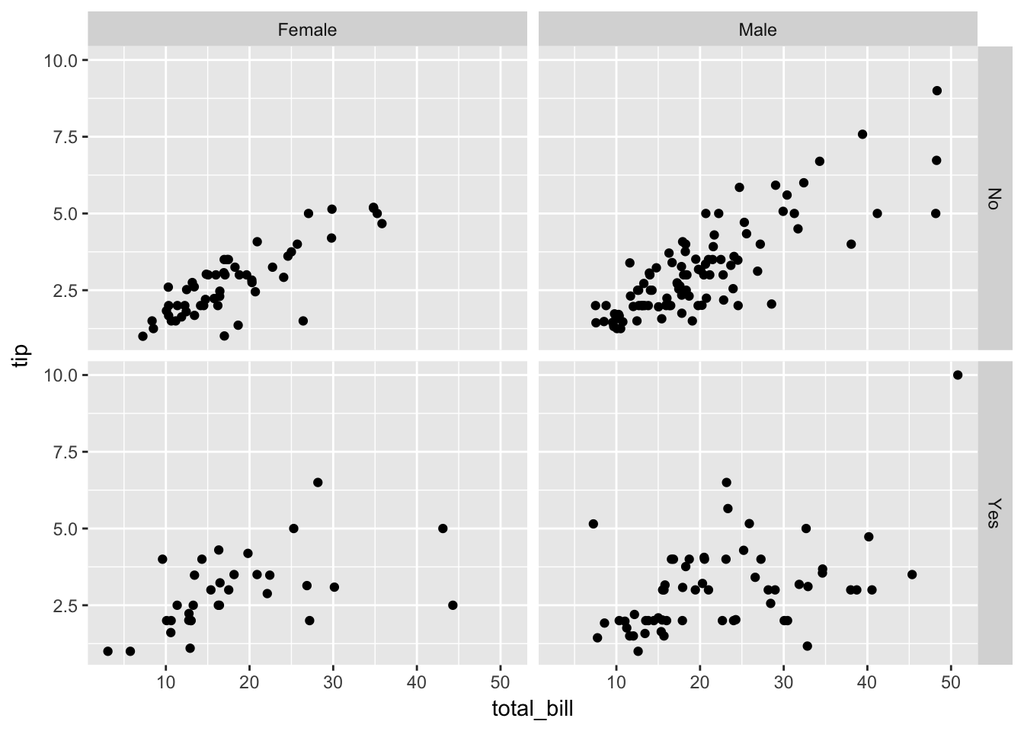

```r
ggplot(data=tips, aes(x=total_bill, y=tip)) + geom_point() +facet_grid(smoker~sex)
```

**There is a clear positive linear relationship between tip amount and total bill for nonsmokers. The correlation is stronger for females than males. There does not appear to be a well defined relationship for those who smoke.**

5. Use ggplot2 to find a graphical summary of the relationship between day of the week and gender of the person paying the bill. What can you say about this relationship?

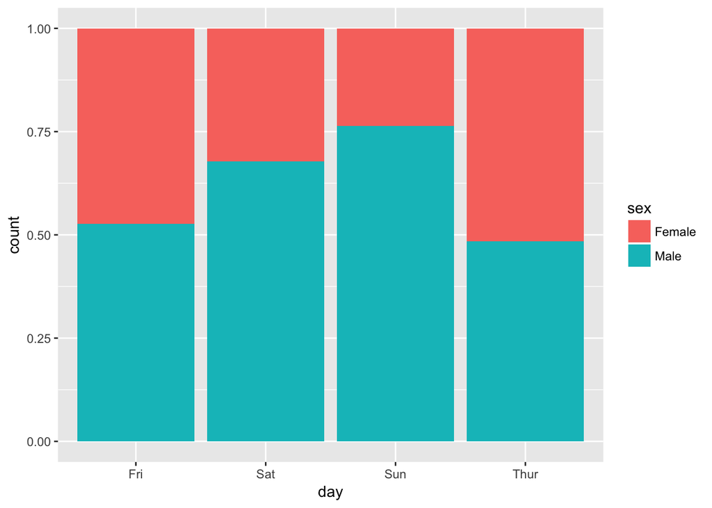

```r
ggplot(tips, aes(x=day, fill=sex)) + geom_bar(position="fill")
```

**On Thursdays and Fridays males and females tend to pay for the bill at an equal amount. On Saturdays and Sundays, males tend to pay for the meal. This indicates that they were perhaps on a date becuase social norms dicate that males pay.**

Note: your submission is supposed to be fully reproducible, i.e. the TA and I will ‘knit’ your submission in RStudio.

For the submission: submit your solution in an R Markdown file and (just for insurance) submit the corresponding html (or Word) file with it.